```python
import pandas as pd
import numpy as np
import matplotlib.pyplot as plt
import seaborn as sns
from sklearn import tree
%matplotlib inline

import warnings
warnings.filterwarnings('ignore')
```

# Importing the file as dataframe

```python
diabetes = pd.read_csv('diabetes.csv')
diabetes.head(10)
```

|  | Pregnancies | Glucose | BloodPressure | SkinThickness | Insulin | BMI | DiabetesPedigreeFunction | Age | Outcome |
| --- | --- | --- | --- | --- | --- | --- | --- | --- | --- |
| 0 | 6 | 148 | 72 | 35 | 0 | 33.6 | 0.627 | 50 | 1 |
| 1 | 1 | 85 | 66 | 29 | 0 | 26.6 | 0.351 | 31 | 0 |
| 2 | 8 | 183 | 64 | 0 | 0 | 23.3 | 0.672 | 32 | 1 |
| 3 | 1 | 89 | 66 | 23 | 94 | 28.1 | 0.167 | 21 | 0 |
| 4 | 0 | 137 | 40 | 35 | 168 | 43.1 | 2.288 | 33 | 1 |
| 5 | 5 | 116 | 74 | 0 | 0 | 25.6 | 0.201 | 30 | 0 |
| 6 | 3 | 78 | 50 | 32 | 88 | 31.0 | 0.248 | 26 | 1 |
| 7 | 10 | 115 | 0 | 0 | 0 | 35.3 | 0.134 | 29 | 0 |
| 8 | 2 | 197 | 70 | 45 | 543 | 30.5 | 0.158 | 53 | 1 |
| 9 | 8 | 125 | 96 | 0 | 0 | 0.0 | 0.232 | 54 | 1 |

The above data is trying to predict the outcome of whether a person is diabetic as a function of the other 8 parameters

There are total 8 independent variable which are all continous and Outcome is target variable. Outcome is a categorical variable and rest all are continous variable in the dataset.

```python
diabetes.describe(include = "all")
```

|  | Pregnancies | Glucose | BloodPressure | SkinThickness | Insulin | BMI | DiabetesPedigreeFunction | Age | Outcome |
| --- | --- | --- | --- | --- | --- | --- | --- | --- | --- |
| count | 768.000000 | 768.000000 | 768.000000 | 768.000000 | 768.000000 | 768.000000 | 768.000000 | 768.000000 | 768.000000 |
| mean | 3.845052 | 120.894531 | 69.105469 | 20.536458 | 79.799479 | 31.992578 | 0.471876 | 33.240885 | 0.348958 |
| std | 3.369578 | 31.972618 | 19.355807 | 15.952218 | 115.244002 | 7.884160 | 0.331329 | 11.760232 | 0.476951 |
| min | 0.000000 | 0.000000 | 0.000000 | 0.000000 | 0.000000 | 0.000000 | 0.078000 | 21.000000 | 0.000000 |
| 25% | 1.000000 | 99.000000 | 62.000000 | 0.000000 | 0.000000 | 27.300000 | 0.243750 | 24.000000 | 0.000000 |
| 50% | 3.000000 | 117.000000 | 72.000000 | 23.000000 | 30.500000 | 32.000000 | 0.372500 | 29.000000 | 0.000000 |
| 75% | 6.000000 | 140.250000 | 80.000000 | 32.000000 | 127.250000 | 36.600000 | 0.626250 | 41.000000 | 1.000000 |
| max | 17.000000 | 199.000000 | 122.000000 | 99.000000 | 846.000000 | 67.100000 | 2.420000 | 81.000000 | 1.000000 |

There are six variables that has minimum value as '0' and out of these variables only 'Pregnancies' variable could take a 'zero' value. The other 'zero' values can be taken as missing values as they are not practical values

Insulin and Skin Thickness parameters has both min and Q1 value as '0' and it suggests that these two parameters has maximum missing values

Checking the info of the dataset for null values and the size of the dataframe

```python
diabetes.info()
```

```
<class 'pandas.core.frame.DataFrame'>
RangeIndex: 768 entries, 0 to 767
Data columns (total 9 columns):
Pregnancies                 768 non-null int64
Glucose                     768 non-null int64
BloodPressure               768 non-null int64
SkinThickness               768 non-null int64
Insulin                     768 non-null int64
BMI                         768 non-null float64
DiabetesPedigreeFunction    768 non-null float64
Age                         768 non-null int64
Outcome                     768 non-null int64
dtypes: float64(2), int64(7)
memory usage: 54.1 KB
```

Visualization of data before data refining

```
array([[<matplotlib.axes._subplots.AxesSubplot object at 0x000001CCCA651B38>,
      dtype=object)
```

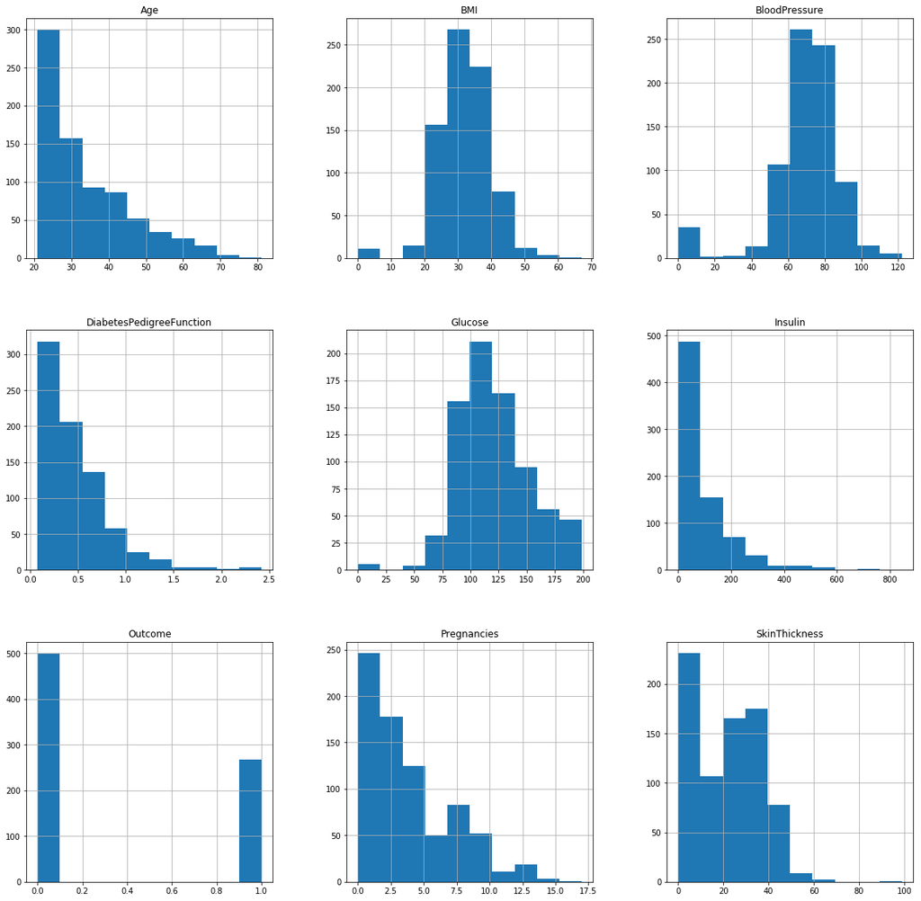

```python
diabetes.hist(figsize = (20,20))
```

```python
#We find that there are '0' values in the dataset which can be missing data.  Before replacing this missing values
#copy the dataframe and then make the required changes

pimadiabetes = diabetes.copy(deep = True)
pimadiabetes.head()
```

|  | Pregnancies | Glucose | BloodPressure | SkinThickness | Insulin | BMI | DiabetesPedigreeFunction | Age | Outcome |
| --- | --- | --- | --- | --- | --- | --- | --- | --- | --- |
| 0 | 6 | 148 | 72 | 35 | 0 | 33.6 | 0.627 | 50 | 1 |
| 1 | 1 | 85 | 66 | 29 | 0 | 26.6 | 0.351 | 31 | 0 |
| 2 | 8 | 183 | 64 | 0 | 0 | 23.3 | 0.672 | 32 | 1 |
| 3 | 1 | 89 | 66 | 23 | 94 | 28.1 | 0.167 | 21 | 0 |
| 4 | 0 | 137 | 40 | 35 | 168 | 43.1 | 2.288 | 33 | 1 |

```python
pimadiabetes.tail()
```

|  | Pregnancies | Glucose | BloodPressure | SkinThickness | Insulin | BMI | DiabetesPedigreeFunction | Age | Outcome |
| --- | --- | --- | --- | --- | --- | --- | --- | --- | --- |
| 763 | 10 | 101 | 76 | 48 | 180 | 32.9 | 0.171 | 63 | 0 |
| 764 | 2 | 122 | 70 | 27 | 0 | 36.8 | 0.340 | 27 | 0 |
| 765 | 5 | 121 | 72 | 23 | 112 | 26.2 | 0.245 | 30 | 0 |
| 766 | 1 | 126 | 60 | 0 | 0 | 30.1 | 0.349 | 47 | 1 |
| 767 | 1 | 93 | 70 | 31 | 0 | 30.4 | 0.315 | 23 | 0 |

There are no null values in the dataset and the dataset has 768 rows and 9 columns.

The 'zero' values can be refined in following ways

- remove the rows with 'zero' values
- replace the 'zero' values with the population mean/median
- replace the 'zero' values with the population mean/median according to the outcome

As there are many zero's in the dataset, it is not advisable to remove the rows and as mean is sensitive to outliers replacing with median is selected

The '0' minimum value for 'Glucose','BMI','SkinThickness','BloodPressure','Insulin' values seems to be impractical. Hence, let us replace these values with Null Values first and after that replace with median value. Median value is choosen as it is not sensitive to outliers present in the dataset

The final outcome depends on the value of 'zero' that we replace and it is better to take the median according to the final outcome i.e., calculate the median of non-diabetic outcome and diabetic outcome separately and replace 0's with these respective medians

1. BLOOD PRESSURE

```python
pimadiabetes[pimadiabetes['BloodPressure'] == 0].shape[0]
```

```
35
```

```python
pimadiabetes[pimadiabetes['BloodPressure'] == 0].index.tolist()
pimadiabetes[pimadiabetes['BloodPressure'] == 0].groupby('Outcome')['BloodPressure'].count()
```

```
Outcome
0    19
1    16
Name: BloodPressure, dtype: int64
```

There are 35 zero values for Blood pressure which can be replaced with median values, out of which 19 are non-diabetic and 16 are diabetic

```python
# Replacing '0' values with null values for column Glucose
pimadiabetes['BloodPressure'].replace(0,np.NaN,inplace = True)
```

```python
# The median value calculation of Glucose grouped by outcome

pimadiabetes_bp = pimadiabetes[pimadiabetes['BloodPressure'].notnull()]
pimadiabetes_bp = pimadiabetes_bp[['BloodPressure','Outcome']].groupby('Outcome')['BloodPressure'].median().reset_index()
pimadiabetes_bp
```

|  | Outcome | BloodPressure |
| --- | --- | --- |
| 0 | 0 | 70.0 |
| 1 | 1 | 74.5 |

Median for '0' Outcome is 70 and '1' Outcome is 74.5

```python
# Replacing the zero values of glucose with the corresponding median values of outcomes as calculated
pimadiabetes.loc[(pimadiabetes['BloodPressure'].isnull()) & (pimadiabetes['Outcome'] == 0),'BloodPressure'] = pimadiabetes_bp['BloodPressure'][0]
pimadiabetes.loc[(pimadiabetes['BloodPressure'].isnull()) & (pimadiabetes['Outcome'] == 1),'BloodPressure'] = pimadiabetes_bp['BloodPressure'][1]
```

```python
pimadiabetes.head(10)
```

|  | Pregnancies | Glucose | BloodPressure | SkinThickness | Insulin | BMI | DiabetesPedigreeFunction | Age | Outcome |
| --- | --- | --- | --- | --- | --- | --- | --- | --- | --- |
| 0 | 6 | 148 | 72.0 | 35 | 0 | 33.6 | 0.627 | 50 | 1 |
| 1 | 1 | 85 | 66.0 | 29 | 0 | 26.6 | 0.351 | 31 | 0 |
| 2 | 8 | 183 | 64.0 | 0 | 0 | 23.3 | 0.672 | 32 | 1 |
| 3 | 1 | 89 | 66.0 | 23 | 94 | 28.1 | 0.167 | 21 | 0 |
| 4 | 0 | 137 | 40.0 | 35 | 168 | 43.1 | 2.288 | 33 | 1 |
| 5 | 5 | 116 | 74.0 | 0 | 0 | 25.6 | 0.201 | 30 | 0 |
| 6 | 3 | 78 | 50.0 | 32 | 88 | 31.0 | 0.248 | 26 | 1 |
| 7 | 10 | 115 | 70.0 | 0 | 0 | 35.3 | 0.134 | 29 | 0 |
| 8 | 2 | 197 | 70.0 | 45 | 543 | 30.5 | 0.158 | 53 | 1 |
| 9 | 8 | 125 | 96.0 | 0 | 0 | 0.0 | 0.232 | 54 | 1 |

```python
# checking for replacement of all '0' values
pimadiabetes[pimadiabetes['BloodPressure'] == 0].shape[0]
```

```
0
```

All zero values of 'BloodPressure' replaced

1. GLUCOSE

```python
#zero values to be replaced
pimadiabetes[pimadiabetes['Glucose'] == 0].shape[0]
```

```
5
```

```python
pimadiabetes[pimadiabetes['Glucose'] == 0].index.tolist()
```

```
[75, 182, 342, 349, 502]
```

```python
pimadiabetes[pimadiabetes['Glucose'] == 0].groupby('Outcome')['Glucose'].count()
```

```
Outcome
0    3
1    2
Name: Glucose, dtype: int64
```

There are only 5 zero values for the Glucose attribute, out of which 3 are for non-diabetic and 2 for diabetic

```python
# Replacing '0' values with null values
pimadiabetes['Glucose'].replace(0,np.NaN,inplace = True)
```

```python
# Calculation of median values grouped according to outcome
pimadiabetes_gl = pimadiabetes[pimadiabetes['Glucose'].notnull()]
pimadiabetes_gl = pimadiabetes_gl[['Glucose','Outcome']].groupby('Outcome').median()
pimadiabetes_gl
```

| Outcome | Glucose |
| --- | --- |
| 0 | 107.0 |
| 1 | 140.0 |

Median for '0' Outcome is 107 and '1' Outcome is 140

```python
pimadiabetes.loc[(pimadiabetes['Glucose'].isnull()) & (pimadiabetes['Outcome'] == 0),'Glucose'] = pimadiabetes_gl['Glucose'][0]
pimadiabetes.loc[(pimadiabetes['Glucose'].isnull()) & (pimadiabetes['Outcome'] == 1),'Glucose'] = pimadiabetes_gl['Glucose'][1]
```

```python
# checking for replacement of all '0' values
pimadiabetes[pimadiabetes['Glucose'] == 0].shape[0]
```

```
0
```

All the zero values of 'Glucose' are replaced

1. BMI

```python
# Selection of data to refine for BMI
pimadiabetes[pimadiabetes['BMI'] == 0].shape[0]
```

```
11
```

```python
pimadiabetes[pimadiabetes['BMI'] == 0].index.tolist()
```

```
[9, 49, 60, 81, 145, 371, 426, 494, 522, 684, 706]
```

```python
pimadiabetes[pimadiabetes['BMI'] == 0].groupby('Outcome')['BMI'].count()
```

```
Outcome
0    9
1    2
Name: BMI, dtype: int64
```

There are 11 zero values to be replaced with median values and 9 are for non-diabetic and 2 for diabetic

```python
# Replacing zero values by NaN values
pimadiabetes['BMI'].replace(0,np.NaN,inplace = True)
```

```python
# Calculating median of the BMI according to outcome
pimadiabetes_bmi = pimadiabetes[pimadiabetes['BMI'].notnull()]
pimadiabetes_bmi = pimadiabetes_bmi[['BMI','Outcome']].groupby('Outcome')['BMI'].median().reset_index()
pimadiabetes_bmi
```

|  | Outcome | BMI |
| --- | --- | --- |
| 0 | 0 | 30.1 |
| 1 | 1 | 34.3 |

Median for '0' Outcome is 30.1 and '1' Outcome is 34.3

```python
# Replacing the Null Values with corresponding median values
pimadiabetes.loc[(pimadiabetes['Outcome'] == 0) & (pimadiabetes['BMI'].isnull()),'BMI'] = pimadiabetes_bmi['BMI'][0]
pimadiabetes.loc[(pimadiabetes['Outcome'] == 1) & (pimadiabetes['BMI'].isnull()),'BMI'] = pimadiabetes_bmi['BMI'][1]
pimadiabetes.head (10)
```

|  | Pregnancies | Glucose | BloodPressure | SkinThickness | Insulin | BMI | DiabetesPedigreeFunction | Age | Outcome |
| --- | --- | --- | --- | --- | --- | --- | --- | --- | --- |
| 0 | 6 | 148.0 | 72.0 | 35 | 0 | 33.6 | 0.627 | 50 | 1 |
| 1 | 1 | 85.0 | 66.0 | 29 | 0 | 26.6 | 0.351 | 31 | 0 |
| 2 | 8 | 183.0 | 64.0 | 0 | 0 | 23.3 | 0.672 | 32 | 1 |
| 3 | 1 | 89.0 | 66.0 | 23 | 94 | 28.1 | 0.167 | 21 | 0 |
| 4 | 0 | 137.0 | 40.0 | 35 | 168 | 43.1 | 2.288 | 33 | 1 |
| 5 | 5 | 116.0 | 74.0 | 0 | 0 | 25.6 | 0.201 | 30 | 0 |
| 6 | 3 | 78.0 | 50.0 | 32 | 88 | 31.0 | 0.248 | 26 | 1 |
| 7 | 10 | 115.0 | 70.0 | 0 | 0 | 35.3 | 0.134 | 29 | 0 |
| 8 | 2 | 197.0 | 70.0 | 45 | 543 | 30.5 | 0.158 | 53 | 1 |
| 9 | 8 | 125.0 | 96.0 | 0 | 0 | 34.3 | 0.232 | 54 | 1 |

```python
# checking for replacement of all '0' values
pimadiabetes[pimadiabetes['BMI'] == 0].shape[0]
```

```
0
```

All zero values of 'BMI' are replaced

1. INSULIN

```python
# CALCULATING NUMBER OF ZERO VALUES
pimadiabetes[pimadiabetes['Insulin'] == 0].shape[0]
pimadiabetes[pimadiabetes['Insulin'] == 0].index.tolist()
pimadiabetes[pimadiabetes['Insulin'] == 0].groupby('Outcome')['Insulin'].count()
```

```
Outcome
0    236
1    138
Name: Insulin, dtype: int64
```

There are 374 zero values to be replaced with respective median values and 236 are for non-diabetic and 138 for diabetic

```python
# Replace zero with Null Values
pimadiabetes['Insulin'].replace(0,np.NaN,inplace = True)
```

```python
# Calculating the median grouped by Outcome
pimadiabetes_ins = pimadiabetes[pimadiabetes['Insulin'].notnull()]
pimadiabetes_ins = pimadiabetes_ins[['Insulin','Outcome']].groupby('Outcome')['Insulin'].median().reset_index()
pimadiabetes_ins
```

|  | Outcome | Insulin |
| --- | --- | --- |
| 0 | 0 | 102.5 |
| 1 | 1 | 169.5 |

Median for '0' Outcome is 102.5 and '1' Outcome is 169.5

```python
# Replacing Null Values with corresponding median values
pimadiabetes.loc[(pimadiabetes['Outcome'] == 0) & (pimadiabetes['Insulin'].isnull()),'Insulin'] = pimadiabetes_ins['Insulin'][0]
pimadiabetes.loc[(pimadiabetes['Outcome'] == 1) & (pimadiabetes['Insulin'].isnull()),'Insulin'] = pimadiabetes_ins['Insulin'][1]
pimadiabetes.head(10)
```

|  | Pregnancies | Glucose | BloodPressure | SkinThickness | Insulin | BMI | DiabetesPedigreeFunction | Age | Outcome |
| --- | --- | --- | --- | --- | --- | --- | --- | --- | --- |
| 0 | 6 | 148.0 | 72.0 | 35 | 169.5 | 33.6 | 0.627 | 50 | 1 |
| 1 | 1 | 85.0 | 66.0 | 29 | 102.5 | 26.6 | 0.351 | 31 | 0 |
| 2 | 8 | 183.0 | 64.0 | 0 | 169.5 | 23.3 | 0.672 | 32 | 1 |
| 3 | 1 | 89.0 | 66.0 | 23 | 94.0 | 28.1 | 0.167 | 21 | 0 |
| 4 | 0 | 137.0 | 40.0 | 35 | 168.0 | 43.1 | 2.288 | 33 | 1 |
| 5 | 5 | 116.0 | 74.0 | 0 | 102.5 | 25.6 | 0.201 | 30 | 0 |
| 6 | 3 | 78.0 | 50.0 | 32 | 88.0 | 31.0 | 0.248 | 26 | 1 |
| 7 | 10 | 115.0 | 70.0 | 0 | 102.5 | 35.3 | 0.134 | 29 | 0 |
| 8 | 2 | 197.0 | 70.0 | 45 | 543.0 | 30.5 | 0.158 | 53 | 1 |
| 9 | 8 | 125.0 | 96.0 | 0 | 169.5 | 34.3 | 0.232 | 54 | 1 |

```python
# checking for replacement of all '0' values
pimadiabetes[pimadiabetes['Insulin'] == 0].shape[0]
```

```
0
```

All '0's of Insulin values are replaced

1. SKIN THICKNESS DATASET

```python
# Checking zero values to be replaced
pimadiabetes[pimadiabetes['SkinThickness'] == 0].shape[0]
pimadiabetes[pimadiabetes['SkinThickness'] == 0].index.tolist()
pimadiabetes[pimadiabetes['SkinThickness'] == 0].groupby('Outcome')['SkinThickness'].count()
```

```
Outcome
0    139
1     88
Name: SkinThickness, dtype: int64
```

There are 227 zero values to be replaced with median values and 139 are for non-diabetic and 88 for diabetic

```python
# Replacing zero values with null values
pimadiabetes['SkinThickness'].replace(0,np.NaN,inplace = True)
```

```python
# Calculating the median values grouped by Outcome
pimadiabetes_skin = pimadiabetes[pimadiabetes['SkinThickness'].notnull()]
pimadiabetes_skin = pimadiabetes_skin[['SkinThickness','Outcome']].groupby('Outcome').median().reset_index()
pimadiabetes_skin
```

|  | Outcome | SkinThickness |
| --- | --- | --- |
| 0 | 0 | 27.0 |
| 1 | 1 | 32.0 |

Median for '0' Outcome is 27 and '1' Outcome is 32

```python
# Replacing the Null Values with the medians calculated
pimadiabetes.loc[(pimadiabetes['Outcome'] == 0) & (pimadiabetes['SkinThickness'].isnull()),'SkinThickness'] = pimadiabetes_skin['SkinThickness'][0]
pimadiabetes.loc[(pimadiabetes['Outcome'] == 1) & (pimadiabetes['SkinThickness'].isnull()),'SkinThickness'] = pimadiabetes_skin['SkinThickness'][1]
pimadiabetes.head(10)
```

|  | Pregnancies | Glucose | BloodPressure | SkinThickness | Insulin | BMI | DiabetesPedigreeFunction | Age | Outcome |
| --- | --- | --- | --- | --- | --- | --- | --- | --- | --- |
| 0 | 6 | 148.0 | 72.0 | 35.0 | 169.5 | 33.6 | 0.627 | 50 | 1 |
| 1 | 1 | 85.0 | 66.0 | 29.0 | 102.5 | 26.6 | 0.351 | 31 | 0 |
| 2 | 8 | 183.0 | 64.0 | 32.0 | 169.5 | 23.3 | 0.672 | 32 | 1 |
| 3 | 1 | 89.0 | 66.0 | 23.0 | 94.0 | 28.1 | 0.167 | 21 | 0 |
| 4 | 0 | 137.0 | 40.0 | 35.0 | 168.0 | 43.1 | 2.288 | 33 | 1 |
| 5 | 5 | 116.0 | 74.0 | 27.0 | 102.5 | 25.6 | 0.201 | 30 | 0 |
| 6 | 3 | 78.0 | 50.0 | 32.0 | 88.0 | 31.0 | 0.248 | 26 | 1 |
| 7 | 10 | 115.0 | 70.0 | 27.0 | 102.5 | 35.3 | 0.134 | 29 | 0 |
| 8 | 2 | 197.0 | 70.0 | 45.0 | 543.0 | 30.5 | 0.158 | 53 | 1 |
| 9 | 8 | 125.0 | 96.0 | 32.0 | 169.5 | 34.3 | 0.232 | 54 | 1 |

```python
# checking for replacement of all '0' values
pimadiabetes[pimadiabetes['SkinThickness'] == 0].shape[0]
```

```
0
```

All zero values of 'SkinThickness' are replaced

```python
pimadiabetes.describe()
```

|  | Pregnancies | Glucose | BloodPressure | SkinThickness | Insulin | BMI | DiabetesPedigreeFunction | Age | Outcome |
| --- | --- | --- | --- | --- | --- | --- | --- | --- | --- |
| count | 768.000000 | 768.000000 | 768.000000 | 768.000000 | 768.000000 | 768.000000 | 768.000000 | 768.000000 | 768.000000 |
| mean | 3.845052 | 121.677083 | 72.389323 | 29.089844 | 141.753906 | 32.434635 | 0.471876 | 33.240885 | 0.348958 |
| std | 3.369578 | 30.464161 | 12.106039 | 8.890820 | 89.100847 | 6.880498 | 0.331329 | 11.760232 | 0.476951 |
| min | 0.000000 | 44.000000 | 24.000000 | 7.000000 | 14.000000 | 18.200000 | 0.078000 | 21.000000 | 0.000000 |
| 25% | 1.000000 | 99.750000 | 64.000000 | 25.000000 | 102.500000 | 27.500000 | 0.243750 | 24.000000 | 0.000000 |
| 50% | 3.000000 | 117.000000 | 72.000000 | 28.000000 | 102.500000 | 32.050000 | 0.372500 | 29.000000 | 0.000000 |
| 75% | 6.000000 | 140.250000 | 80.000000 | 32.000000 | 169.500000 | 36.600000 | 0.626250 | 41.000000 | 1.000000 |
| max | 17.000000 | 199.000000 | 122.000000 | 99.000000 | 846.000000 | 67.100000 | 2.420000 | 81.000000 | 1.000000 |

```python
# Number of persons who are diabetic at an early age
pimadiabetes[pimadiabetes['Age']<30].count()
```

```
Pregnancies                 396
Glucose                     396
BloodPressure               396
SkinThickness               396
Insulin                     396
BMI                         396
DiabetesPedigreeFunction    396
Age                         396
Outcome                     396
dtype: int64
```

```python
pimadiabetes[(pimadiabetes['Age']<30) & (pimadiabetes['Outcome'] == 1)].count()
```

```
Pregnancies                 84
Glucose                     84
BloodPressure               84
SkinThickness               84
Insulin                     84
BMI                         84
DiabetesPedigreeFunction    84
Age                         84
Outcome                     84
dtype: int64
```

Out of 396 persons with age less than 30, 84 Persons are diabetic

```python
# Number of persons who are not diabetic at age > 60
pimadiabetes[pimadiabetes['Age']>50].count()
```

```
Pregnancies                 81
Glucose                     81
BloodPressure               81
SkinThickness               81
Insulin                     81
BMI                         81
DiabetesPedigreeFunction    81
Age                         81
Outcome                     81
dtype: int64
```

```python
pimadiabetes[(pimadiabetes['Age']>50) & (pimadiabetes['Outcome'] == 0)].count()
```

```
Pregnancies                 43
Glucose                     43
BloodPressure               43
SkinThickness               43
Insulin                     43
BMI                         43
DiabetesPedigreeFunction    43
Age                         43
Outcome                     43
dtype: int64
```

VISUALISATION OF DATA AFTER DATA REFINING

1. Univariate analysis of the data

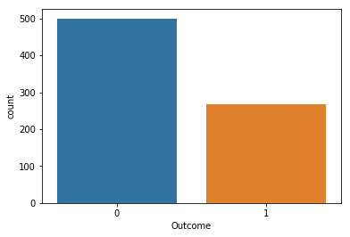

```python
sns.countplot(x = 'Outcome', data = pimadiabetes)
```

```
array([[<matplotlib.axes._subplots.AxesSubplot object at 0x000001CCC7483898>,
      dtype=object)
```

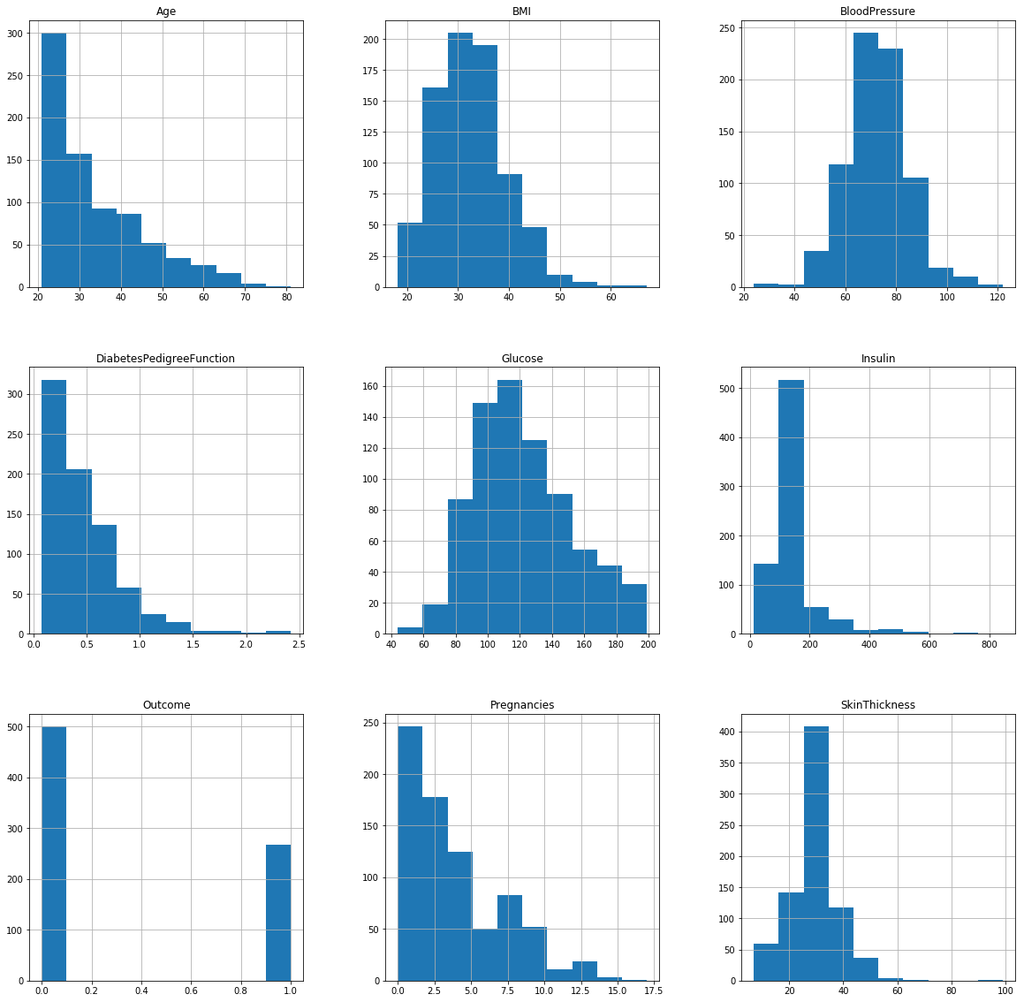

```python
# Histogram
pimadiabetes.hist(figsize = (20,20))
```

```
Pregnancies                    AxesSubplot(0.125,0.657941;0.227941x0.222059)
Glucose                     AxesSubplot(0.398529,0.657941;0.227941x0.222059)
BloodPressure               AxesSubplot(0.672059,0.657941;0.227941x0.222059)
SkinThickness                  AxesSubplot(0.125,0.391471;0.227941x0.222059)
Insulin                     AxesSubplot(0.398529,0.391471;0.227941x0.222059)
BMI                         AxesSubplot(0.672059,0.391471;0.227941x0.222059)
DiabetesPedigreeFunction          AxesSubplot(0.125,0.125;0.227941x0.222059)
Age                            AxesSubplot(0.398529,0.125;0.227941x0.222059)
Outcome                        AxesSubplot(0.672059,0.125;0.227941x0.222059)
dtype: object
```

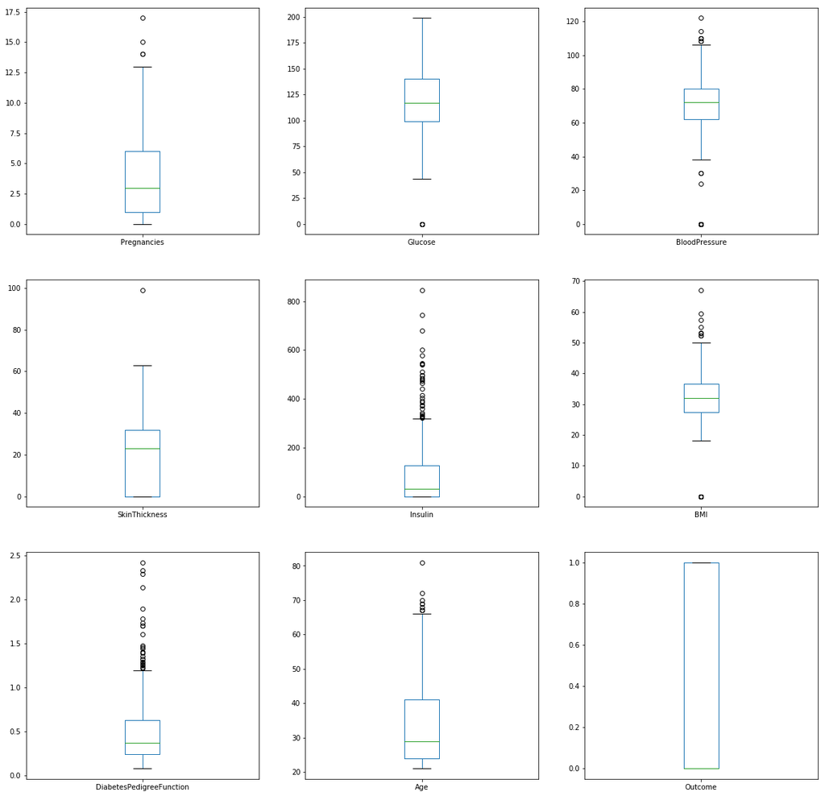

```python
# boxplot for the unrefined data
diabetes.plot(kind = 'box',figsize = (20,20), subplots = True, layout = (3,3))
```

SkinThickness parameters is having only one outlier i.e., its maximum value with Q1 as '0' and insulin also has Q1 value as '0' as they have many '0' values

```
Pregnancies                    AxesSubplot(0.125,0.657941;0.227941x0.222059)
Glucose                     AxesSubplot(0.398529,0.657941;0.227941x0.222059)
BloodPressure               AxesSubplot(0.672059,0.657941;0.227941x0.222059)
SkinThickness                  AxesSubplot(0.125,0.391471;0.227941x0.222059)
Insulin                     AxesSubplot(0.398529,0.391471;0.227941x0.222059)
BMI                         AxesSubplot(0.672059,0.391471;0.227941x0.222059)
DiabetesPedigreeFunction          AxesSubplot(0.125,0.125;0.227941x0.222059)
Age                            AxesSubplot(0.398529,0.125;0.227941x0.222059)
Outcome                        AxesSubplot(0.672059,0.125;0.227941x0.222059)
dtype: object
```

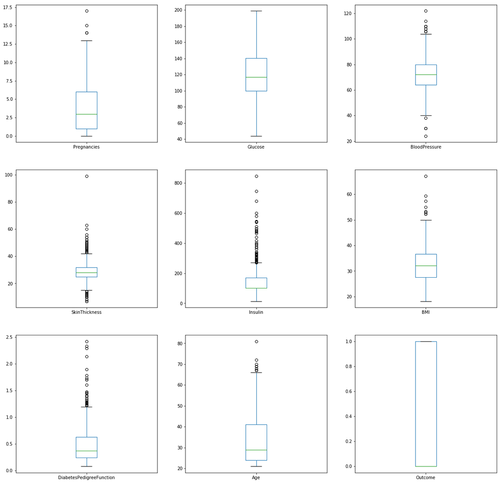

```python
#Boxplot for the refined data
pimadiabetes.plot(kind = 'box',figsize = (20,20), subplots = True, layout = (3,3))
```

1. Glucose value doesnot have an Outlier
2. Insulin, DiabetesPedigreeFunction and SkinThicknesss are having many outliers, in which SkinThickness has outliers both at lower and higher value side

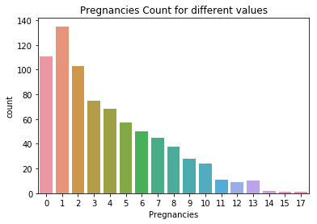

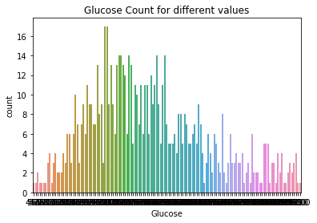

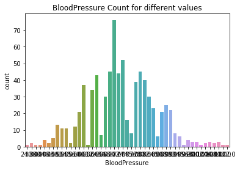

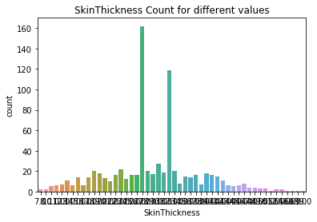

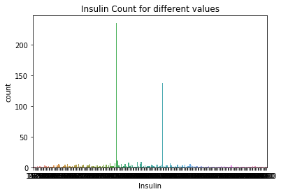

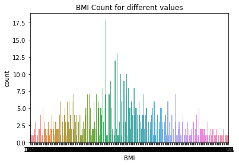

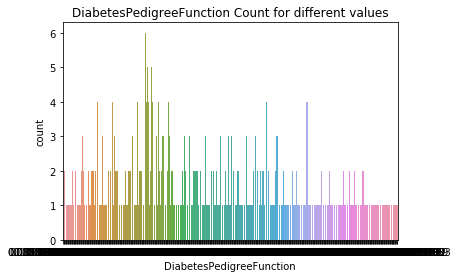

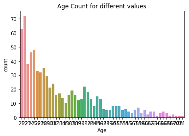

```python
col = pimadiabetes.columns[:8]
for item in col:

    plt.title( str(item) + ' Count' + ' for' + ' different' + ' values')
    sns.countplot( x= pimadiabetes[item],data = pimadiabetes)
    plt.show()
```

Less data is available for older women compared to younger ones and hence the count of women with outcome '0' is more than the Outcome '1'

1. Bivariate analysis

Plotting all the continous variables against the target variable

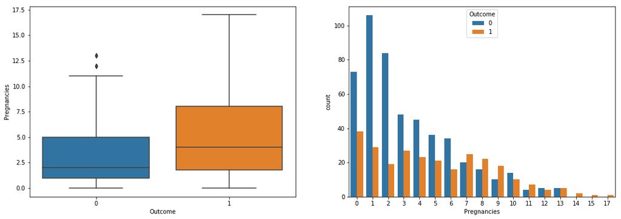

```python
fig, axes = plt.subplots(1, 2, figsize=(18, 6))
sns.boxplot(x='Outcome', y='Pregnancies', data=pimadiabetes, ax=axes[0])
sns.countplot(pimadiabetes['Pregnancies'], hue = pimadiabetes['Outcome'], ax=axes[1])
```

The mean of the women who are diabetic is more than that of non-diabetic as can be seen in the histogram also.

Comparison of various parameters by dividing data into different age groups

```python
pimadiabetes['age_group'] = pd.cut(pimadiabetes['Age'], range(0, 100, 10))
```

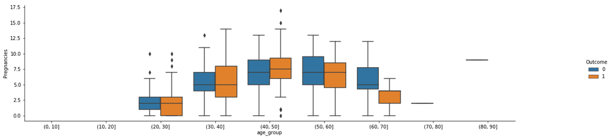

```python
g = sns.catplot(x="age_group", y="Pregnancies", hue="Outcome",
               data=pimadiabetes, kind="box"
              )
g.fig.set_figheight(4)
g.fig.set_figwidth(20)
```

Women with age between 30 - 60 years of age are prone to diabetic and it seems the distribution is also normal

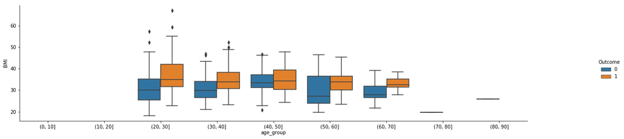

```python
g = sns.catplot(x="age_group", y="BMI", hue="Outcome",
               data=pimadiabetes, kind="box"
              )
g.fig.set_figheight(4)
g.fig.set_figwidth(20)
```

BMI variation doesnot seem to depend on age group

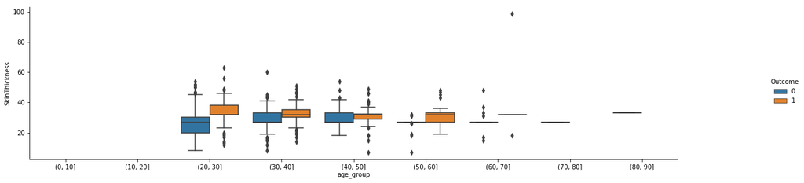

```python
g = sns.catplot(x="age_group", y="SkinThickness", hue="Outcome",
               data=pimadiabetes, kind="box"
              )
g.fig.set_figheight(4)
g.fig.set_figwidth(20)
```

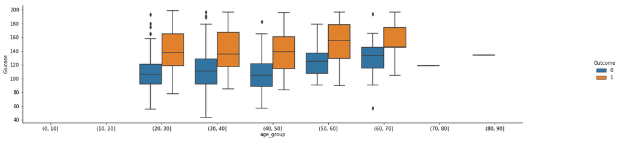

```python
g = sns.catplot(x="age_group", y="Glucose", hue="Outcome",
               data=pimadiabetes, kind="box"
              )
g.fig.set_figheight(4)
g.fig.set_figwidth(20)
```

swarmplot for independent variables against target variable for unrefined data

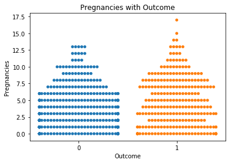

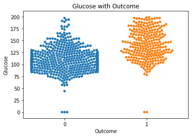

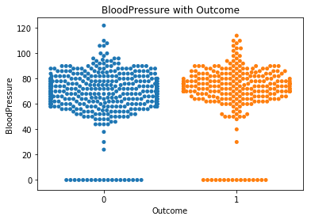

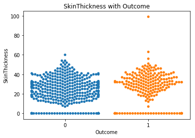

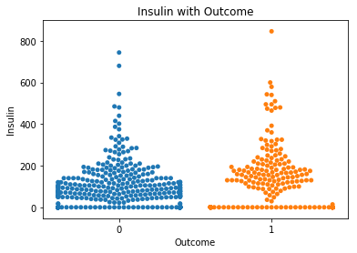

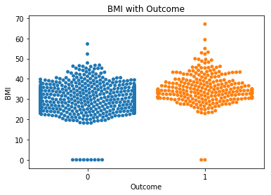

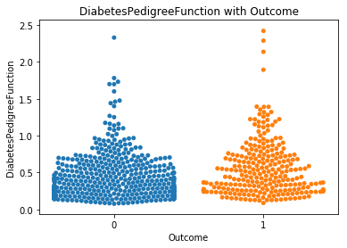

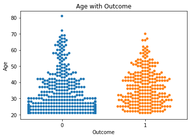

```python
col = diabetes.columns[:8]
for item in col:

    plt.title( str(item) +  ' with'  +   ' Outcome')
    sns.swarmplot(x = diabetes.Outcome, y = diabetes[item],data = diabetes)
    plt.show()
```

For insulin data, there are many 'zero' values and so Q1,Medium has become '0' for Outcome 1 and for Outcome 0, Q1 value is 0